# AssignmentWriteup

Bodhi Goswami

1/12/2022

**Practical Machine Learning Assignment Writeup**

The data is to predict the variable *classe* which describes how well an exercise was done. My assumption was NA values concludes that data was not recorded, in other words that exercise was not done. Hence i filled in all NA values as Zero. For this initially I created a function to fill NA values to Zero, changed all data that should be numeric to numeric variable and changed classe variable to factor.

```r
processme <- function(dataset) {

  dataset[is.na(dataset)==TRUE] <- 0
  dataset[dataset == "#DIV/0!"] <- 0

  dataset[is.na(dataset)==TRUE] <- 0
  dataset[dataset == "#DIV/0!"] <- 0

  dataset$cvtd_timestamp <- NULL

  dataset$new_window <- ifelse(dataset$new_window == "yes", 1, 0)

  character_ok <- c("user_name","classe")
  dataset_charok <- dataset[,character_ok]
  dataset_tonum <- dataset[,!(names(dataset) %in% (character_ok))]
  dataset_tonum <- data.frame(sapply(dataset_tonum, as.numeric))

  dataset<- cbind(dataset_tonum,dataset_charok); rm(dataset_tonum,dataset_charok,character_ok)
  dataset$classe <- as.factor(dataset$classe)

  return(dataset)
}

train <- processme(train)
test <- processme(test)
```

Each variable provides a value for ID number of the individual, denoted by X. Below is a plot of a variable “pitch arm” over “X”.

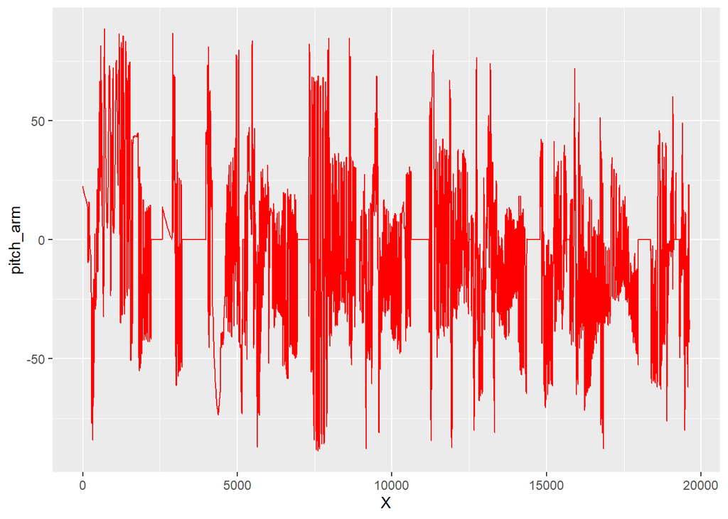

```r
g = ggplot (data=train, aes(x = X, y = pitch_arm))
g = g + geom_line(col="red")
g
```

I used GBM model to predict the outcome.I used **crossvalidation** by using “repeatedcv” option in trainControl.

```r
trainID <- createDataPartition(train$classe, p=0.7, list = FALSE)
training <- train[trainID,] ; val <- train[-trainID,]

myControl <- trainControl(method = "repeatedcv", number = 5, repeats = 3)

#Train data
modFit.gbm <- train(classe~.-X-user_name, data = training,
                    tuneGrid = expand.grid(n.trees = 150,
                                           interaction.depth=3,
                                           shrinkage = 0.1,
                                           n.minobsinnode = 10),
                    method = "gbm",
                    trControl = myControl, verbose = FALSE)

pred_gbm <- predict(modFit.gbm, val)
```

```r
confusionMatrix(pred_gbm,val$classe)
confusionMatrix(predict(modFit.gbm, training),training$classe)
```

[output not shown]

I ran the model with entire train data to create my final prediction.

```r
#Running this model on entire data
#Train data
modFit.gbm.fullmodel <- train(classe~.-X-user_name, data = train,
                    tuneGrid = expand.grid(n.trees = 150,
                                           interaction.depth=3,
                                           shrinkage = 0.1,
                                           n.minobsinnode = 10),
                    method = "gbm",
                    trControl = myControl, verbose = FALSE)

pred <- predict(modFit.gbm.fullmodel,test)
predicted_data <- data.frame(X = test$X,
                             user_name = test$user_name,
                             classe = pred)
```

Upon testing out a few algorithms I found out this model works best for the given data. That drove me to make the choices I made.

Hope you had a good read. This was short and informative. I appreciate your time.